# Data Science Design Patterns – Source Code Examples in R

Dmitrij Petrov

### Design Pattern #1: Notebook in R

The application of `Notebook` design pattern can be seen throughout this `.Rmd` file, underpinned by the `RMarkdown` package https://rmarkdown.rstudio.com/.

### Design Pattern #2: Data Frame in R

Create a 3-by-2 data frame using `tibble` library.

```r
library(tibble) # loads the package
tibble(col1 = 1:3, col2=c("e", "f", "g"))
```

```
## # A tibble: 3 x 2
##    col1 col2
##   <int> <chr>
## 1     1 e
## 2     2 f
## 3     3 g
```

Alternatively using `data.table`.

```r
library(data.table)
data.table(col1 = 1:3, col2=c("e", "f", "g"))
```

```
##    col1 col2
## 1:    1    e
## 2:    2    f
## 3:    3    g
```

Unload packages in order to avoid conflicts.

```r
detach("package:data.table", unload=F)
```

### Design Pattern #3: Tidy Data in R

Using `Data Frame Design Pattern` and `tibble` library, create a 3-by-4 table.

```r
library(tibble)
dp_4 <- tibble(Types = c("Sedan", "SUV", "Sports car"),
               William = c(1,0,2), Monica = c(0,2,NA),
               Johan = c(0,1,1))
head(dp_4) # display a dataset
```

```
## # A tibble: 3 x 4
##   Types      William Monica Johan
##   <chr>        <dbl>  <dbl> <dbl>
## 1 Sedan           1.     0.    0.
## 2 SUV             0.     2.    1.
## 3 Sports car      2.    NA     1.
```

Next, reshape the data using `tidyr` package.

```r
library(tidyr)
tidy_df <- gather(data = dp_4, key = "first_name",
                          value = "cars_owned", 2:4)
head(tidy_df, n = 6) # display first 6 rows
```

```
## # A tibble: 6 x 3
##   Types      first_name cars_owned
##   <chr>      <chr>           <dbl>
## 1 Sedan      William            1.
## 2 SUV        William            0.
## 3 Sports car William            2.
## 4 Sedan      Monica             0.
## 5 SUV        Monica             2.
## 6 Sports car Monica            NA
```

Same functionality provided by `reshare2` library.

```r
library(reshape2)
reshape_df <- melt(dp_4, id = "Types", variable.name = "first_name", value.name = "car_owned")
head(reshape_df, n = 3)
```

```
##        Types first_name car_owned
## 1      Sedan    William         1
## 2        SUV    William         0
## 3 Sports car    William         2
```

```r
detach("package:reshape2", unload=F)
detach("package:tidyr", unload=F)
```

### Design Pattern #4: Leakage in R

Topic/Task: Imputing missing data in the `air quality data set`.

```r
library(mice)
library(datasets)
set.seed(32018)
data("airquality")
```

Inspect what is missing in the dataset.

```r
summary(airquality)
```

```
##      Ozone           Solar.R           Wind             Temp
##  Min.   :  1.00   Min.   :  7.0   Min.   : 1.700   Min.   :56.00
##  1st Qu.: 18.00   1st Qu.:115.8   1st Qu.: 7.400   1st Qu.:72.00
##  Median : 31.50   Median :205.0   Median : 9.700   Median :79.00
##  Mean   : 42.13   Mean   :185.9   Mean   : 9.958   Mean   :77.88
##  3rd Qu.: 63.25   3rd Qu.:258.8   3rd Qu.:11.500   3rd Qu.:85.00
##  Max.   :168.00   Max.   :334.0   Max.   :20.700   Max.   :97.00
##  NA's   :37       NA's   :7
##      Month            Day
##  Min.   :5.000   Min.   : 1.0
##  1st Qu.:6.000   1st Qu.: 8.0
##  Median :7.000   Median :16.0
##  Mean   :6.993   Mean   :15.8
##  3rd Qu.:8.000   3rd Qu.:23.0
##  Max.   :9.000   Max.   :31.0
##
```

```r
md.pattern(airquality)
```

```
##     Wind Temp Month Day Solar.R Ozone
## 111    1    1     1   1       1     1  0
##  35    1    1     1   1       1     0  1
##   5    1    1     1   1       0     1  1
##   2    1    1     1   1       0     0  2
##        0    0     0   0       7    37 44
```

```r
imp <- mice(airquality, m = 5, maxit = 5, method = "pmm")
completeAirQuality <- complete(imp)
summary(completeAirQuality)
```

```
##      Ozone           Solar.R           Wind             Temp
##  Min.   :  1.00   Min.   :  7.0   Min.   : 1.700   Min.   :56.00
##  1st Qu.: 18.00   1st Qu.:118.0   1st Qu.: 7.400   1st Qu.:72.00
##  Median : 32.00   Median :203.0   Median : 9.700   Median :79.00
##  Mean   : 40.99   Mean   :185.9   Mean   : 9.958   Mean   :77.88
##  3rd Qu.: 52.00   3rd Qu.:259.0   3rd Qu.:11.500   3rd Qu.:85.00
##  Max.   :168.00   Max.   :334.0   Max.   :20.700   Max.   :97.00
##      Month            Day
##  Min.   :5.000   Min.   : 1.0
##  1st Qu.:6.000   1st Qu.: 8.0
##  Median :7.000   Median :16.0
##  Mean   :6.993   Mean   :15.8
##  3rd Qu.:8.000   3rd Qu.:23.0
##  Max.   :9.000   Max.   :31.0
```

The summary statistics have remained very similar.

### Design Pattern #5: Prototyping in R

Data come from https://archive.ics.uci.edu/ml/datasets/pima+indians+diabetes

Topic/Task: Classifying whether females of Pima Indian heritage have diabetes, from medical records data.

```r
library(caret)
library(mlbench)             # for the dataset
library(pROC)

set.seed(32018)              # ensure reproducibility of results
data(PimaIndiansDiabetes)    # contains train + test data
```

Which data type are variables? Source: https://stackoverflow.com/a/23907642

Select only those which are integer & numeric.

```r
df_variables <- split(names(PimaIndiansDiabetes),
                      sapply(PimaIndiansDiabetes, function(x) paste(class(x), collapse=" ")))
input_colNames <- unlist(df_variables[2])
```

After acquisition, data are split into training (75%) and testing (25%) subsets using `caret` library.

```r
library(caret)
splitIndex <- createDataPartition(PimaIndiansDiabetes$diabetes, p = .75,
                    list = FALSE, times = 1)
trainDataFrame <- PimaIndiansDiabetes[ splitIndex,]
testDataFrame  <- PimaIndiansDiabetes[-splitIndex,]

training <- trainDataFrame[,input_colNames] # select only input variables
trainDiabetesCl <- trainDataFrame$diabetes  # store output class separately

testesting <- testDataFrame[,input_colNames]
testDiabetesCl <- testDataFrame$diabetes
```

Train a classification model using `k-nearest neighbors` algorithm and predict new values that can be used later in the confusion matrix.

```r
trMod <- train(
          y=trainDiabetesCl, x=training, # training dataset -- vector and variables
          method ='kknn',                # k-nearest neighbors from kknn package
          metric = "ROC",                # metric for evaluation
          trControl=trainControl(classProbs = TRUE,
                                 summaryFunction = twoClassSummary))

predictions <- predict(object=trMod, newdata=testesting, type='raw')
```

```r
print(postResample(pred=predictions, obs=testDiabetesCl))
```

```
##  Accuracy     Kappa
## 0.7291667 0.3955685
```

```r
pROC::multiclass.roc(testDiabetesCl, predict(object=trMod, testesting, type='prob')[[2]])
```

```
##
## Call:
## multiclass.roc.default(response = testDiabetesCl, predictor = predict(object = trMod,     testesting, type = "prob")[[2]])
##
## Data: predict(object = trMod, testesting, type = "prob")[[2]] with 2 levels of testDiabetesCl: neg, pos.
## Multi-class area under the curve: 0.8093
```

### Design Pattern #6: Cross-validation in R

Continuation with above data set. Using `caret` library, one can specify a training control function which includes how to split data, see next.

```r
ctrlFunc1 <- trainControl(
              method = "cv", number = 5,        # 5-fold cross validation
              summaryFunction = twoClassSummary,# binary classification
              classProbs = T)                   # task
```

### Design Pattern #7: Grid in R

Training a naive Bayes classification model and applying `Cross-validation Design Pattern`.

```r
library(caret)
ctrlFunc1 <- trainControl(
              method = "cv", number = 5,        # 5-fold cross validation
              summaryFunction = twoClassSummary,# binary classification
              classProbs = T)                   # task

predModel <- train(
              y=trainDiabetesCl, x=training,  # training dataset -- vector and variables
              method='nb',              # naive Bayes from klaR package
              trControl=ctrlFunc1,      # training control function
              metric = "ROC",           # metric for evaluating the model
              tuneGrid=expand.grid(     # search 2^3 = 8 combinations in the grid
                fL=c(0.1,0.2),          # 2 values for penalty
                usekernel=c(TRUE,FALSE),# whether kernel or normal density
                adjust=c(0.4,0.5)))     # bandwidth adjustment
```

Now, evaluate prediction using AUC ROC.

```r
print(predModel)
```

```
## Naive Bayes
##
## 576 samples
##   8 predictor
##   2 classes: 'neg', 'pos'
##
## No pre-processing
## Resampling: Cross-Validated (5 fold)
## Summary of sample sizes: 461, 461, 461, 461, 460
## Resampling results across tuning parameters:
##
##   fL   usekernel  adjust  ROC        Sens       Spec
##   0.1  FALSE      0.4     0.8074309  0.8453333  0.6020732
##   0.1  FALSE      0.5     0.8074309  0.8453333  0.6020732
##   0.1   TRUE      0.4     0.8111106  0.8586667  0.5873171
##   0.1   TRUE      0.5     0.8124602  0.8506667  0.5873171
##   0.2  FALSE      0.4     0.8074309  0.8453333  0.6020732
##   0.2  FALSE      0.5     0.8074309  0.8453333  0.6020732
##   0.2   TRUE      0.4     0.8111106  0.8586667  0.5873171
##   0.2   TRUE      0.5     0.8124602  0.8506667  0.5873171
##
## ROC was used to select the optimal model using the largest value.
## The final values used for the model were fL = 0.1, usekernel = TRUE
##  and adjust = 0.5.
```

```r
predictions1 <- predict(object=predModel, testesting, type='raw')
predictions2 <- predict(object=predModel, testesting, type='prob')

print(postResample(pred=predictions1, obs=testDiabetesCl))
```

```
##  Accuracy     Kappa
## 0.7343750 0.4253521
```

```r
auc <- multiclass.roc(testDiabetesCl, predictions2[[2]])
auc
```

```
##
## Call:
## multiclass.roc.default(response = testDiabetesCl, predictor = predictions2[[2]])
##
## Data: predictions2[[2]] with 2 levels of testDiabetesCl: neg, pos.
## Multi-class area under the curve: 0.8339
```

When using `cross-validation` and `grid search`, Kappa is ~ 0.43 with accuracy ~ 0.74. These are quite good results (a slight increase from using just classical holdout set). Nonetheless, can we achieve better results?

### Design Pattern #8: Assemblage in R

Considering the same example from previous pattern, this one uses `caretEnsemble` package.

```r
library(caret)
library(caretEnsemble)
library(glmnet)
library(pls)

ctrlFunc2 <- trainControl(
              method = "cv", number = 5,    # 5-fold cross validation
              summaryFunction = twoClassSummary,
              savePredictions="final",
              index = createResample(trainDiabetesCl, 10),
              classProbs = T)

model_list <- caretList(
  y=trainDiabetesCl, x=training,
  trControl=ctrlFunc2,
  metric="ROC",             # the same metric from 'Grid #8'
  methodList=c("pls", "nb") # Partial Least Squares + naive Bayes methods for ensemble
)
```

```r
print(model_list)
```

```
## $pls
## Partial Least Squares
##
## 576 samples
##   8 predictor
##   2 classes: 'neg', 'pos'
##
## No pre-processing
## Resampling: Cross-Validated (5 fold)
## Summary of sample sizes: 576, 576, 576, 576, 576, 576, ...
## Resampling results across tuning parameters:
##
##   ncomp  ROC        Sens       Spec
##   1      0.6784215  0.9400648  0.1626575
##   2      0.7955362  0.8909436  0.4631809
##   3      0.8025638  0.8884761  0.4806470
##
## ROC was used to select the optimal model using the largest value.
## The final value used for the model was ncomp = 3.
##
## $nb
## Naive Bayes
##
## 576 samples
##   8 predictor
##   2 classes: 'neg', 'pos'
##
## No pre-processing
## Resampling: Cross-Validated (5 fold)
## Summary of sample sizes: 576, 576, 576, 576, 576, 576, ...
## Resampling results across tuning parameters:
##
##   usekernel  ROC        Sens       Spec
##   FALSE      0.8233711  0.8573010  0.5998729
##    TRUE      0.8179740  0.8466583  0.6012516
##
## Tuning parameter 'fL' was held constant at a value of 0
## Tuning
##  parameter 'adjust' was held constant at a value of 1
## ROC was used to select the optimal model using the largest value.
## The final values used for the model were fL = 0, usekernel = FALSE
##  and adjust = 1.
##
## attr(,"class")
## [1] "caretList"
```

See for instance `pls` (partial least squares) model’s performance (which is also quite high ~ kappa is about 0.47).

```r
predictions3 <- predict(object=model_list[1], testesting, type='raw')
predictions4 <- predict(object=model_list[1], testesting, type='prob')

print(postResample(pred=predictions3[[1]], obs=testDiabetesCl))
```

```
##  Accuracy     Kappa
## 0.7708333 0.4775510
```

```r
auc <- pROC::multiclass.roc(testDiabetesCl, predictions4$pls$pos)
auc
```

```
##
## Call:
## multiclass.roc.default(response = testDiabetesCl, predictor = predictions4$pls$pos)
##
## Data: predictions4$pls$pos with 2 levels of testDiabetesCl: neg, pos.
## Multi-class area under the curve: 0.8179
```

Check for correlation between models.

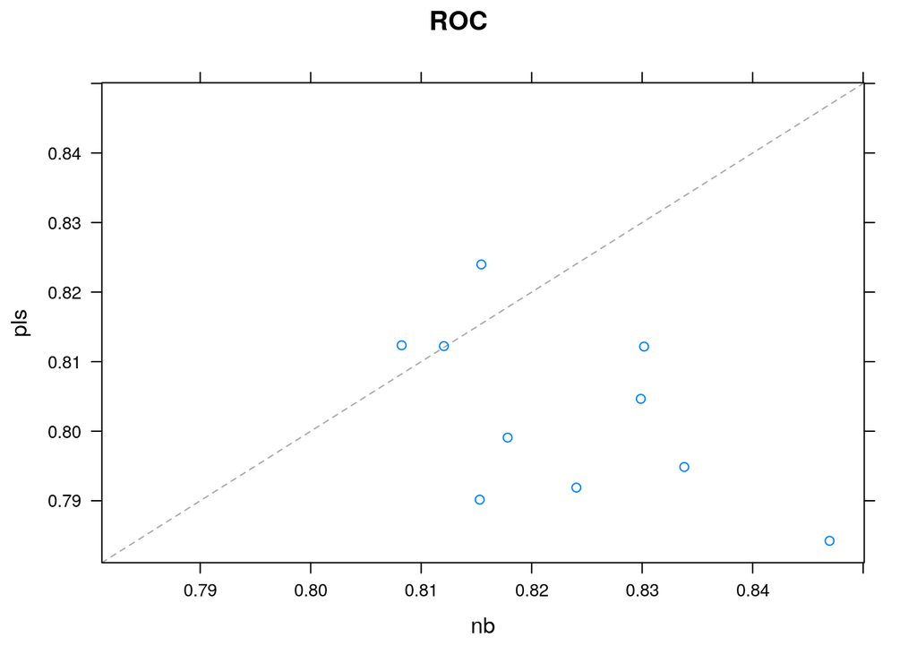

```r
xyplot(resamples(model_list))
```

```r
modelCor(resamples(model_list))
```

```
##            pls         nb
## pls  1.0000000 -0.5577005
## nb  -0.5577005  1.0000000
```

There is some correlation, but let’s try to apply ensemble anyway to see if it is going to improve the performance. We use here `stacking` approach where we combine `pls` (partial least squares) and `nb` (naive Bayes) through `generalized linear models` algorithm.

```r
greedy_ensemble <- caretStack(
  model_list,
  method="glmnet",
  tuneLength=5,
  metric="ROC",
  trControl=trainControl(
    method="cv",
    number=5,  # 5-fold cross-validation
    savePredictions="final",
    summaryFunction=twoClassSummary,
    classProbs=TRUE
))

greedy_ensemble
```

```
## A glmnet ensemble of 2 base models: pls, nb
##
## Ensemble results:
## glmnet
##
## 2146 samples
##    2 predictor
##    2 classes: 'neg', 'pos'
##
## No pre-processing
## Resampling: Cross-Validated (5 fold)
## Summary of sample sizes: 1717, 1717, 1717, 1717, 1716
## Resampling results across tuning parameters:
##
##   alpha  lambda       ROC        Sens       Spec
##   0.100  0.001074728  0.8187910  0.8729563  0.5463087
##   0.100  0.004988445  0.8187814  0.8729563  0.5463087
##   0.100  0.023154310  0.8186520  0.8772369  0.5409396
##   0.100  0.107472788  0.8186713  0.8979283  0.4939597
##   0.325  0.001074728  0.8187623  0.8729563  0.5463087
##   0.325  0.004988445  0.8187766  0.8729563  0.5463087
##   0.325  0.023154310  0.8188150  0.8779487  0.5409396
##   0.325  0.107472788  0.8187095  0.9036401  0.4791946
##   0.550  0.001074728  0.8188245  0.8729563  0.5463087
##   0.550  0.004988445  0.8188293  0.8729563  0.5463087
##   0.550  0.023154310  0.8188292  0.8793772  0.5395973
##   0.550  0.107472788  0.8188575  0.9100635  0.4671141
##   0.775  0.001074728  0.8188053  0.8729563  0.5476510
##   0.775  0.004988445  0.8187909  0.8729563  0.5463087
##   0.775  0.023154310  0.8188720  0.8800890  0.5395973
##   0.775  0.107472788  0.8192404  0.9143467  0.4469799
##   1.000  0.001074728  0.8187909  0.8729563  0.5476510
##   1.000  0.004988445  0.8188244  0.8736680  0.5463087
##   1.000  0.023154310  0.8189340  0.8800890  0.5409396
##   1.000  0.107472788  0.8192207  0.9207677  0.4295302
##
## ROC was used to select the optimal model using the largest value.
## The final values used for the model were alpha = 0.775 and lambda
##  = 0.1074728.
```

Now predict using an ensemble of two methods.

```r
library(caTools)
model_predsStack <- lapply(model_list, predict, newdata=testesting, type="prob")
model_predsStack <- lapply(model_predsStack, function(x) x[,"pos"])
model_predsStack <- data.frame(model_predsStack)

model_predsStack$ensemble <- predict(greedy_ensemble, newdata=testesting, type="prob")

colAUC(model_predsStack, testDiabetesCl)
```

```
##                   pls        nb  ensemble
## neg vs. pos 0.8179104 0.8248358 0.8336716
```

```r
auc2 <- pROC::multiclass.roc(testDiabetesCl, model_predsStack$ensemble)
auc2
```

```
##
## Call:
## multiclass.roc.default(response = testDiabetesCl, predictor = model_predsStack$ensemble)
##
## Data: model_predsStack$ensemble with 2 levels of testDiabetesCl: neg, pos.
## Multi-class area under the curve: 0.8337
```

Indeed, it shows very modest improvement in prediction at round 0.83, which is better than individual predictions using naive Bayes and partial least squares.

### Design Pattern #9: Interactive Application in R

For seeing the `Interactive Application` using `Shiny` framework, the reader has to open `RStudio IDE` and its project `code_data.Rproj` from this folder. Then, once navigating to the `/dp_9/R-Shiny` folder within the application and opening the `app.R` file, a green button will be available to run the Shiny application on the local computer.

### Design Pattern #10: Cloud in R

See `README.md` file in the `dp_10` folder, `R_DP_10.Rmd` respectively.